# Análisis estadístico de datos del “Kepler Space Observatory (KSO)” objetos de interés candidatos a ser exoplanetas

Santiago Escamilla del Angel, Andre Sebastián García Ward, Ricardo Covarrubias Yeffal,José Miguel Rodriguez Barrera

25/01/2022

INTRODUCCIÓN El observatorio “The Kepler Space Observatory (KSO)” es un satélite hecho por la NASA que fue puesto en órbita en 2009. El objetivo de este observatorio es la búsqueda de exoplanetas en sistemas solares ajenos al nuestro con el objetivo primordial de encontrar otros planetas habitables. Este objetivo fue olvidado debido a fallas mecánicas del satélite, sin embargo sigue en uso para otros fines.

La base de datos que se va a utilizar en este proyecto contiene aproximadamente 10,000 observaciones de “objetos de interés”, que son básicamente candidatos a ser exoplanetas, hechos por KSO hasta el año 2017.

La fuente de esta base de datos se encuentra en el siguiente enlace: https://www.kaggle.com/nasa/kepler-exoplanet-search-results , sin embargo en dicho enlace se hace referencia a la base de datos orginal que se encuentra en: https://exoplanetarchive.ipac.caltech.edu/docs/data.html , mismo enlace en el que podemos encontrar un diccionario de la terminología que se usa en la base de datos (cuyo enlace explícito es https://exoplanetarchive.ipac.caltech.edu/docs/API_kepcandidate_columns.html). Fue de gran utilidad para este proyecto tener este diccionario, ya que nos permitió leer claramente la base de datos.

OBJETIVO -Aplicar diferentes métodos de análisis estadístico al conjunto de datos ante señalado

Descripción de las variables

Hay tres variables cuantitativas y una cualitativa asociadas a los exoplanetas y dos variables cuantitativas asociadas a los soles de sus sistemas.

Variables de los Exoplanetas (de razón, salvo por la cualitativa):

| Tipo de Variable | Nombre de la Variable | Descripción |
| --- | --- | --- |
| Cuantitativa | Temperatura de Equilibrio (K) (koi_teq) | “Una aproximación para la temperatura del planeta. Este cálculo asume las siguientes consideraciones: Equilibrio termodinámico entre el flujo estelar y el calor irradiado del planeta. Enlace de Albedo… |
| Cuantitativa | Radio del planeta (Radios terrestres) (koi_prad) | “El radio planetario es el producto del radio de la estrella del planeta con el radio estelar.” Para conseguir el periodo de los planetas no es posible medir de forma igual que como se hace con planet… |
| Cuantitativa | Periodo del planeta (días) (koi_period) | “El intervalo de tiempo entre tránsito planetario consecutivo.” Ya conocemos esta variable, por lo que no se requiere mayor explicación. |
| Cualitativa | Disposición del planeta (koi_disposition) | “Los valores que se pueden admitir son CANDIDATO, FALSO POSITIVO, SIN DISPOSICIÓN ó CONFIRMADO.” La variable clasifica a los planetas dentro de una lista en los que los que califican como candidatos o… |

Variables de los soles de los exoplanetas (de razón)

| Tipo de Variable | Nombre de la Variable | Descripción |
| --- | --- | --- |
| Cuantitativa | Radio (radios terrestres) (koi_srad) | “El radio fotosférico de la estrella.” Es importante recalcar que los radios de soles muchas veces se miden con respecto al radio de la fotosfera. Esta es la superficie luminosa que delimita al cuerpo… |
| Cuantitativa | Temperatura efectiva (K) (koi_steff) | “Las temperatura fotosférica de la estrella.” Al analizar la fotosfera debemos de saber que ella es una capa de gases que vista con telescopios muestra folículos y bordes, con lo cual es fácil darle u… |

```r
library(rio)
exo_planetas_p1<- read.csv('/Users/114738/OneDrive/Escritorio/Proyectos/cumulative.csv');
```

Seleccionamos las variables que nos interesan

```r
library(dplyr)
exo_planetas_p2 <- dplyr::select(exo_planetas_p1, kepoi_name, koi_disposition ,koi_period, koi_prad, koi_teq, koi_srad,koi_steff)
```

```r
library(tidyr)
exo_planetas_p3 = exo_planetas_p2 %>% group_by(kepoi_name) %>%
dplyr::filter (! duplicated(kepoi_name))

library(tidyr)
exo_planetas_p4 = tidyr::drop_na(exo_planetas_p3)
attach(exo_planetas_p4)
```

Para la variable temperatura realizamos el análisis exploratorio, similar al de la actividad 2:

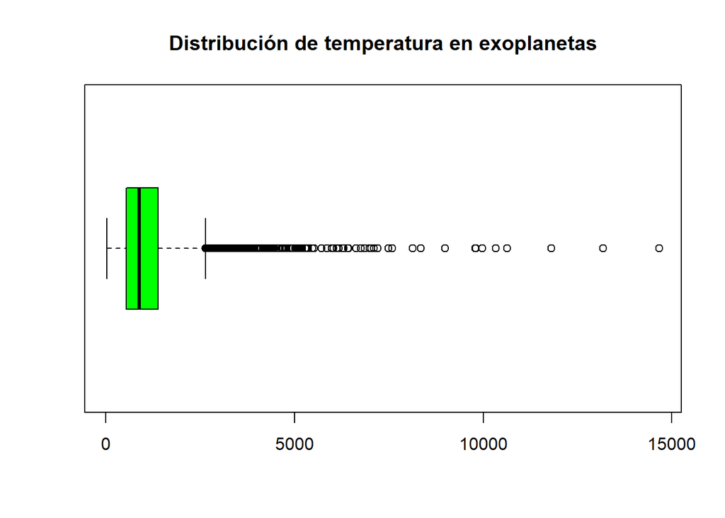

```r
caja_temp <- boxplot(exo_planetas_p4$koi_teq,horizontal=T,col="green",main="Distribución de temperatura en exoplanetas")
```

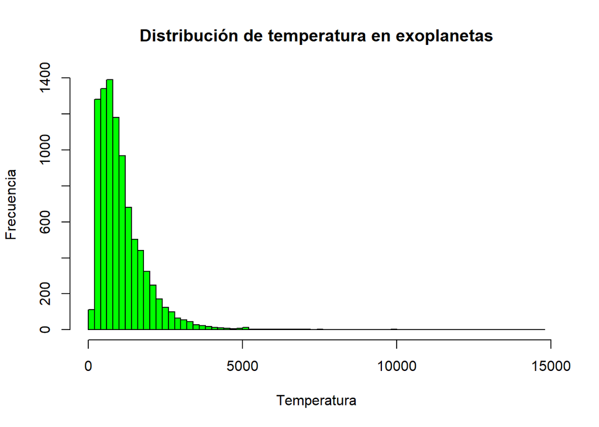

```r
hist_temp <- hist(exo_planetas_p4$koi_teq, main = "Distribución de temperatura en exoplanetas", xlab = "Temperatura", ylab = "Frecuencia", col = "green", breaks = 70)
```

```r
n <- length(hist_temp$breaks)
Tab_pl_temp <- cbind(hist_temp$breaks[-n],hist_temp$breaks[-1],
                hist_temp$counts,
                hist_temp$counts/sum(hist_temp$counts),
                cumsum(hist_temp$counts),
                cumsum(hist_temp$counts/sum(hist_temp$counts)))
dimnames(Tab_pl_temp)[[2]]<-c("Linf","Lsup","f","fr","F","Fr")

print(Tab_pl_temp)
```

```
##        Linf  Lsup    f           fr    F         Fr
##  [1,]     0   200  112 0.0121725899  112 0.01217259
##  [2,]   200   400 1283 0.1394413651 1395 0.15161396
##  [3,]   400   600 1341 0.1457450277 2736 0.29735898
##  [4,]   600   800 1390 0.1510705358 4126 0.44842952
##  [5,]   800  1000 1181 0.1283556135 5307 0.57678513
##  [6,]  1000  1200  969 0.1053146397 6276 0.68209977
##  [7,]  1200  1400  682 0.0741223780 6958 0.75622215
##  [8,]  1400  1600  503 0.0546679709 7461 0.81089012
##  [9,]  1600  1800  442 0.0480382567 7903 0.85892838
## [10,]  1800  2000  325 0.0353222476 8228 0.89425062
## [11,]  2000  2200  249 0.0270622758 8477 0.92131290
## [12,]  2200  2400  171 0.0185849364 8648 0.93989784
## [13,]  2400  2600  124 0.0134767960 8772 0.95337463
## [14,]  2600  2800   99 0.0107597000 8871 0.96413433
```

[output cut: 60 more lines]

```r
library(fdth)
mean(exo_planetas_p4$koi_teq)
```

```
## [1] 1085.386
```

```r
median(exo_planetas_p4$koi_teq)
```

```
## [1] 878
```

```r
mfv(exo_planetas_p4$koi_teq)
```

```
## [1] 523
```

```r
max(exo_planetas_p4$koi_teq)
```

```
## [1] 14667
```

```r
min(exo_planetas_p4$koi_teq)
```

```
## [1] 25
```

```r
range(exo_planetas_p4$koi_teq)
```

```
## [1]    25 14667
```

```r
var(exo_planetas_p4$koi_teq)
```

```
## [1] 733337.3
```

```r
sd(exo_planetas_p4$koi_teq)
```

```
## [1] 856.3512
```

```r
mad(exo_planetas_p4$koi_teq)
```

```
## [1] 575.2488
```

```r
quantile(exo_planetas_p4$koi_teq, probs = c(0.25,0.50,0.75))
```

```
##  25%  50%  75%
##  539  878 1379
```

En primer lugar podemos ver que hay una clara tendencia de los valores hacia la izquierda, es decir que la mayoría de los datos que se obtuvieron indican que los planetas tienen temperaturas absolutas similares entre sí, esto se ve justificado por el cálculo cuantil de los datos. Si buscamos realizar conclusiones necesitaríamos conocer a profundidad los métodos con los cuales se realizaron las observaciones. Sin embargo la tendencia se va a repetir bastante en las siguientes variables.

También podemos notar que existen valores que parecen ser errores de observación. Hay tres datos, aunque podrían ser alrededor de 10, que sobresalen por completo de la gráfica de caja por tener, al parecer, una temperatura extremadamente alta. Sin embargo, como no tenemos suficiente información, no podemos concluir demasiado, únicamente destacar que hay varios datos (entre tres o diez) que parecen no pertenecer a la base de datos.

Finalmente, podemos ver que la varianza es muy grade, esto implica que la medida del promedio no es nada confiable.

Para el radio de los planetas:

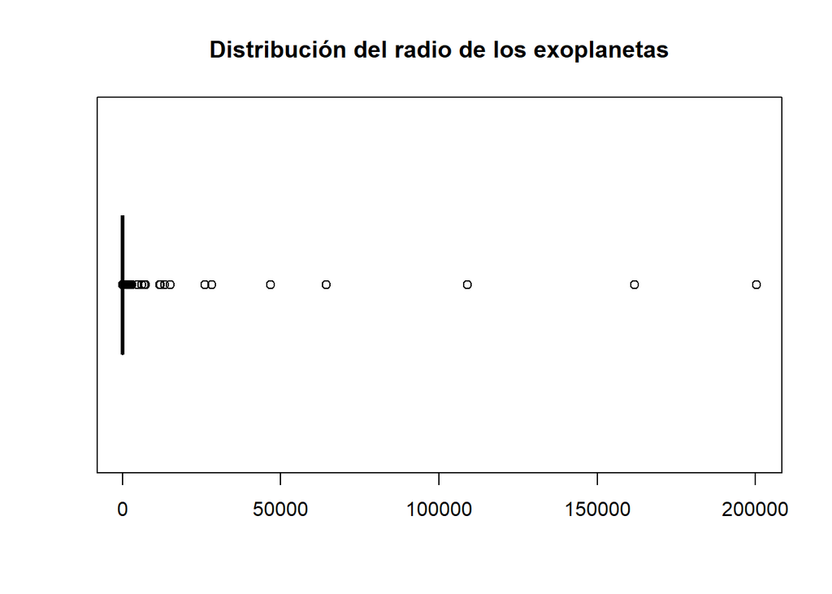

```r
caja_prad <- boxplot(exo_planetas_p4$koi_prad,horizontal=T,col="green", main="Distribución del radio de los exoplanetas")
```

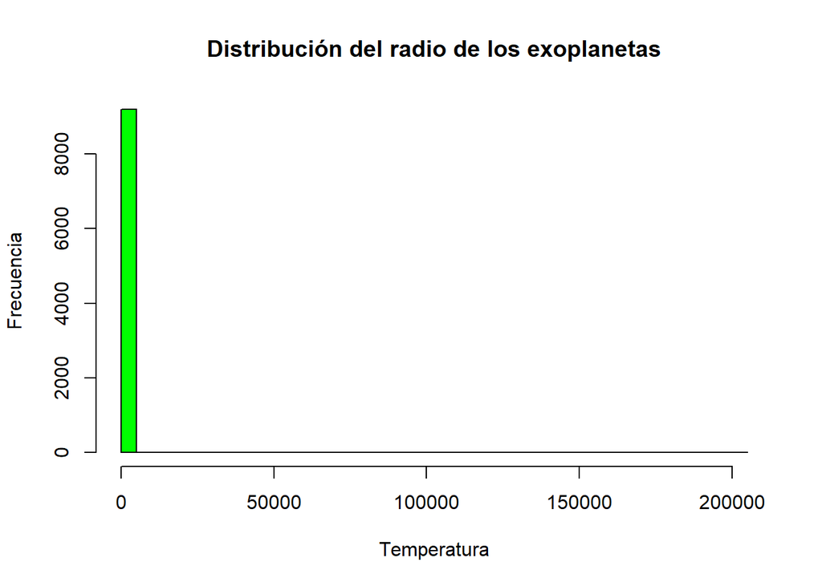

```r
hist_prad <- hist(exo_planetas_p4$koi_prad, main = "Distribución del radio de los exoplanetas", xlab = "Temperatura", ylab = "Frecuencia", col = "green", breaks = 70)
```

```r
n <- length(hist_prad$breaks)
Tab_pl_prad <- cbind(hist_prad$breaks[-n],hist_prad$breaks[-1],
                hist_prad$counts,
                hist_prad$counts/sum(hist_prad$counts),
                cumsum(hist_prad$counts),
                cumsum(hist_prad$counts/sum(hist_prad$counts)))
dimnames(Tab_pl_prad)[[2]]<-c("Linf","Lsup","f","fr","F","Fr")

print(Tab_pl_prad)
```

```
##         Linf   Lsup    f           fr    F        Fr
##  [1,]      0   5000 9185 0.9982610586 9185 0.9982611
##  [2,]   5000  10000    4 0.0004347354 9189 0.9986958
##  [3,]  10000  15000    3 0.0003260515 9192 0.9990218
##  [4,]  15000  20000    2 0.0002173677 9194 0.9992392
##  [5,]  20000  25000    0 0.0000000000 9194 0.9992392
##  [6,]  25000  30000    2 0.0002173677 9196 0.9994566
##  [7,]  30000  35000    0 0.0000000000 9196 0.9994566
##  [8,]  35000  40000    0 0.0000000000 9196 0.9994566
##  [9,]  40000  45000    0 0.0000000000 9196 0.9994566
## [10,]  45000  50000    1 0.0001086838 9197 0.9995653
## [11,]  50000  55000    0 0.0000000000 9197 0.9995653
## [12,]  55000  60000    0 0.0000000000 9197 0.9995653
## [13,]  60000  65000    1 0.0001086838 9198 0.9996739
## [14,]  65000  70000    0 0.0000000000 9198 0.9996739
```

[output cut: 27 more lines]

```r
library(fdth)
mean(exo_planetas_p4$koi_prad)
```

```
## [1] 102.8918
```

```r
median(exo_planetas_p4$koi_prad)
```

```
## [1] 2.39
```

```r
mfv(exo_planetas_p4$koi_prad)
```

```
## [1] 1.08
```

```r
max(exo_planetas_p4$koi_prad)
```

```
## [1] 200346
```

```r
min(exo_planetas_p4$koi_prad)
```

```
## [1] 0.08
```

```r
range(exo_planetas_p4$koi_prad)
```

```
## [1]      0.08 200346.00
```

```r
var(exo_planetas_p4$koi_prad)
```

```
## [1] 9471863
```

```r
sd(exo_planetas_p4$koi_prad)
```

```
## [1] 3077.639
```

```r
mad(exo_planetas_p4$koi_prad)
```

```
## [1] 1.942206
```

```r
quantile(exo_planetas_p4$koi_prad, probs = c(0.25,0.50,0.75))
```

```
##   25%   50%   75%
##  1.40  2.39 14.93
```

En primer lugar podemos ver la tendencia de los valores es muy parecida a la de los datos anteriores, es decir que la mayoría de los datos que se obtuvieron indican que los planetas tienen radios similares entre sí, nuevamente esto se ve justificado por el cálculo cuantil de los datos.

Nuevamente podemos notar que existen valores que parecen ser errores de observación. Hay siete datos, aunque podrían diez, que sobresalen por completo de la gráfica de caja por tener un radio enorme. En este caso las conclusiones son menos contundentes que en el caso anterior, ya que se conocen planetas con un radio mucho mayor al de la tierra, sin embargo esto parece que es demasiado, sin embargo, nuevamente no contamos con demasiada información y es relevante destacar que hay varios datos que parecen no pertenecer a la base de datos.

Nuevamente vemos que la varianza es muy grade y por tanto la medida del promedio no es nada confiable.

Para el periodo de los planetas

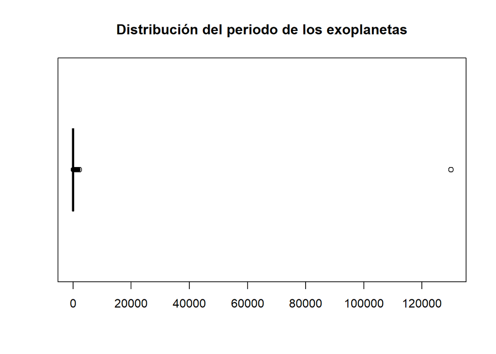

```r
caja_period <- boxplot(exo_planetas_p4$koi_period,horizontal=T,col="green", main="Distribución del periodo de los exoplanetas")
```

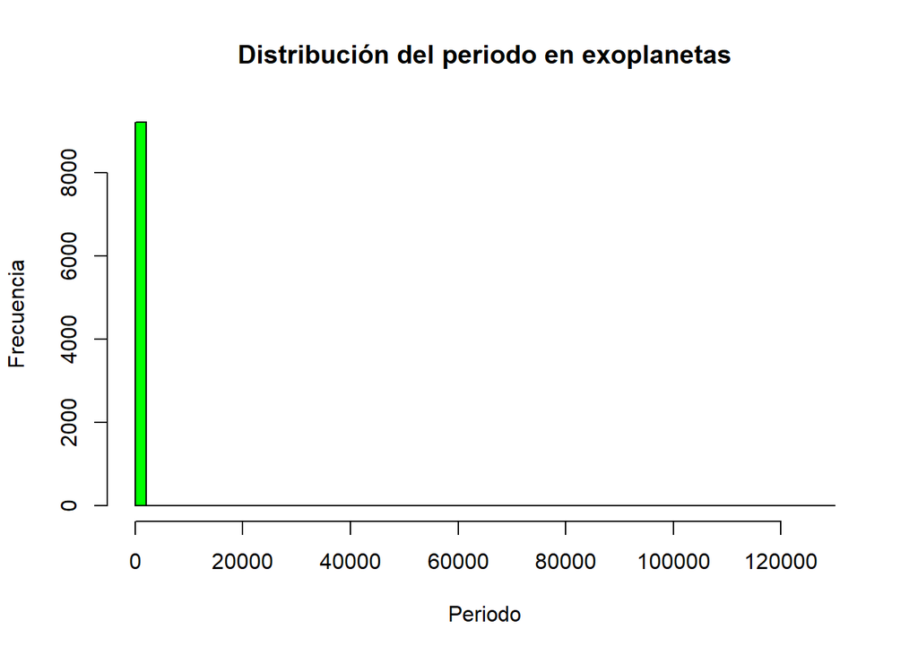

```r
hist_period <- hist(exo_planetas_p4$koi_period, main = "Distribución del periodo en exoplanetas", xlab = "Periodo", ylab = "Frecuencia", col = "green", breaks = 70)
```

```r
n <- length(hist_period$breaks)
Tab_pl_period <- cbind(hist_period$breaks[-n],hist_period$breaks[-1],
                hist_period$counts,
                hist_period$counts/sum(hist_period$counts),
                cumsum(hist_period$counts),
                cumsum(hist_period$counts/sum(hist_period$counts)))
dimnames(Tab_pl_period)[[2]]<-c("Linf","Lsup","f","fr","F","Fr")

print(Tab_pl_period)
```

```
##         Linf   Lsup    f           fr    F        Fr
##  [1,]      0   2000 9199 0.9997826323 9199 0.9997826
##  [2,]   2000   4000    1 0.0001086838 9200 0.9998913
##  [3,]   4000   6000    0 0.0000000000 9200 0.9998913
##  [4,]   6000   8000    0 0.0000000000 9200 0.9998913
##  [5,]   8000  10000    0 0.0000000000 9200 0.9998913
##  [6,]  10000  12000    0 0.0000000000 9200 0.9998913
##  [7,]  12000  14000    0 0.0000000000 9200 0.9998913
##  [8,]  14000  16000    0 0.0000000000 9200 0.9998913
##  [9,]  16000  18000    0 0.0000000000 9200 0.9998913
## [10,]  18000  20000    0 0.0000000000 9200 0.9998913
## [11,]  20000  22000    0 0.0000000000 9200 0.9998913
## [12,]  22000  24000    0 0.0000000000 9200 0.9998913
## [13,]  24000  26000    0 0.0000000000 9200 0.9998913
## [14,]  26000  28000    0 0.0000000000 9200 0.9998913
```

[output cut: 51 more lines]

```r
library(fdth)
mean(exo_planetas_p4$koi_period)
```

```
## [1] 74.30795
```

```r
median(exo_planetas_p4$koi_period)
```

```
## [1] 9.296746
```

```r
mfv(exo_planetas_p4$koi_period)
```

```
## [1] 9.488036
```

```r
max(exo_planetas_p4$koi_period)
```

```
## [1] 129995.8
```

```r
min(exo_planetas_p4$koi_period)
```

```
## [1] 0.2418425
```

```r
range(exo_planetas_p4$koi_period)
```

```
## [1] 2.418425e-01 1.299958e+05
```

```r
var(exo_planetas_p4$koi_period)
```

```
## [1] 1851066
```

```r
sd(exo_planetas_p4$koi_period)
```

```
## [1] 1360.539
```

```r
mad(exo_planetas_p4$koi_period)
```

```
## [1] 11.96274
```

```r
quantile(exo_planetas_p4$koi_period, probs = c(0.25,0.50,0.75))
```

```
##       25%       50%       75%
##  2.682768  9.296746 36.856776
```

Nuevamente la tendencia de los valores es muy parecida a la de los datos anteriores y la mayoría de los datos que se obtuvieron indican que los planetas tienen periodos similares entre sí, nuevamente esto se ve justificado por el cálculo cuantil de los datos.

Nuevamente podemos notar que existe un valor que parece ser un error de observación. El dato sobresale por completo de la gráfica de caja por tener un periodo exageradamente grande. En este caso las conclusiones son mucho menos contundentes que en el caso anterior ya que no contamos con información suficiente para determinar si esto es posible.

De nuevo la varianza es muy grade y por tanto la medida del promedio no es nada confiable.

Para el radio del Sol

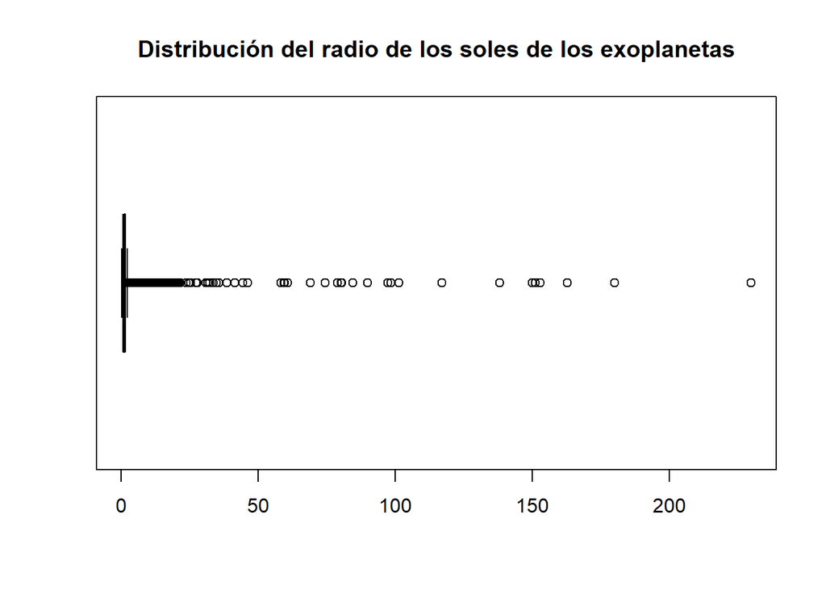

```r
caja_radS <- boxplot(exo_planetas_p3$koi_srad,horizontal=T,col="green", main="Distribución del radio de los soles de los exoplanetas")
```

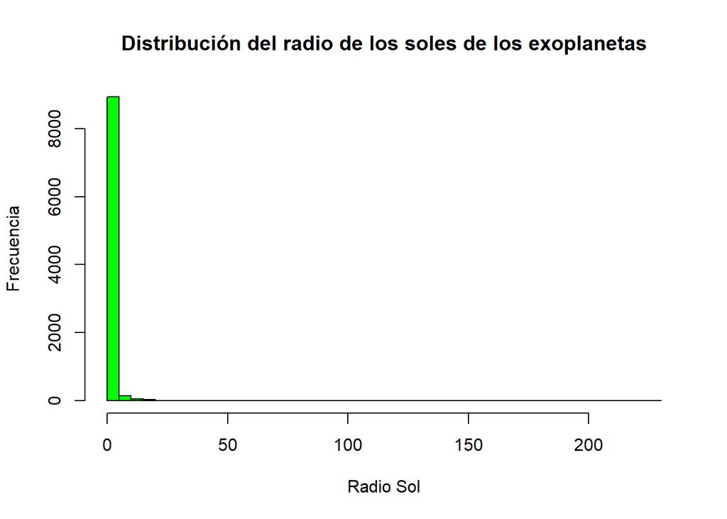

```r
hist_radS <- hist(exo_planetas_p3$koi_srad, main = "Distribución del radio de los soles de los exoplanetas", xlab = "Radio Sol", ylab = "Frecuencia", col = "green", breaks = 70)
```

```r
n <- length(hist_radS$breaks)
Tab_pl_radS <- cbind(hist_radS$breaks[-n],hist_radS$breaks[-1],
                hist_radS$counts,
                hist_radS$counts/sum(hist_radS$counts),
                cumsum(hist_radS$counts),
                cumsum(hist_radS$counts/sum(hist_radS$counts)))
dimnames(Tab_pl_radS)[[2]]<-c("Linf","Lsup","f","fr","F","Fr")

print(Tab_pl_radS)
```

```
##       Linf Lsup    f           fr    F        Fr
##  [1,]    0    5 8927 0.9702206282 8927 0.9702206
##  [2,]    5   10  146 0.0158678405 9073 0.9860885
##  [3,]   10   15   54 0.0058689273 9127 0.9919574
##  [4,]   15   20   29 0.0031518313 9156 0.9951092
##  [5,]   20   25    7 0.0007607869 9163 0.9958700
##  [6,]   25   30    3 0.0003260515 9166 0.9961961
##  [7,]   30   35    5 0.0005434192 9171 0.9967395
##  [8,]   35   40    3 0.0003260515 9174 0.9970655
##  [9,]   40   45    3 0.0003260515 9177 0.9973916
## [10,]   45   50    1 0.0001086838 9178 0.9975003
## [11,]   50   55    0 0.0000000000 9178 0.9975003
## [12,]   55   60    3 0.0003260515 9181 0.9978263
## [13,]   60   65    1 0.0001086838 9182 0.9979350
## [14,]   65   70    1 0.0001086838 9183 0.9980437
```

[output cut: 32 more lines]

```r
library(fdth)
mean(exo_planetas_p4$koi_srad)
```

```
## [1] 1.728712
```

```r
median(exo_planetas_p4$koi_srad)
```

```
## [1] 1
```

```r
mfv(exo_planetas_p4$koi_srad)
```

```
## [1] 1
```

```r
max(exo_planetas_p4$koi_srad, na.rm = FALSE)
```

```
## [1] 229.908
```

```r
min(exo_planetas_p4$koi_srad)
```

```
## [1] 0.109
```

```r
range(exo_planetas_p4$koi_srad)
```

```
## [1]   0.109 229.908
```

```r
var(exo_planetas_p4$koi_srad)
```

```
## [1] 37.54239
```

```r
sd(exo_planetas_p4$koi_srad)
```

```
## [1] 6.127185
```

```r
mad(exo_planetas_p4$koi_srad)
```

```
## [1] 0.3068982
```

```r
quantile(exo_planetas_p4$koi_srad, probs = c(0.25,0.50,0.75))
```

```
##   25%   50%   75%
## 0.829 1.000 1.345
```

Como podemos observar se sigue la misma tendencia que vimos en el análisis de las variables cuantitativas de los exoplanetas. Nuevamente los datos indican que la mayoría de los radios de los soles son parecidos entre sí. La mayor diferencia con los datos que se obtuvieron previamente es que los datos que sobresalen de los rangos es un poco mayor, son al menos diez valores que parecen no pertenecer al conjunto de datos, esto se puede dar por errores de medición o porque en realidad si haya soles con un radio de ese tamaño, sin embargo no contamos con la información suficiente como para conocer las razones por las que eso sucedió.

También hay otra diferencia en el análisis de estos datos, vemos que en este caso la varianza no es muy grande, por lo que las medidas del promedio no son del todo desconfiables, esto se debe a que la cantidad de datos que parecen no pertenecer a la base de datos es considerablemente mayor a las de las variables anteriores.

Para la temperatura efectiva del Sol

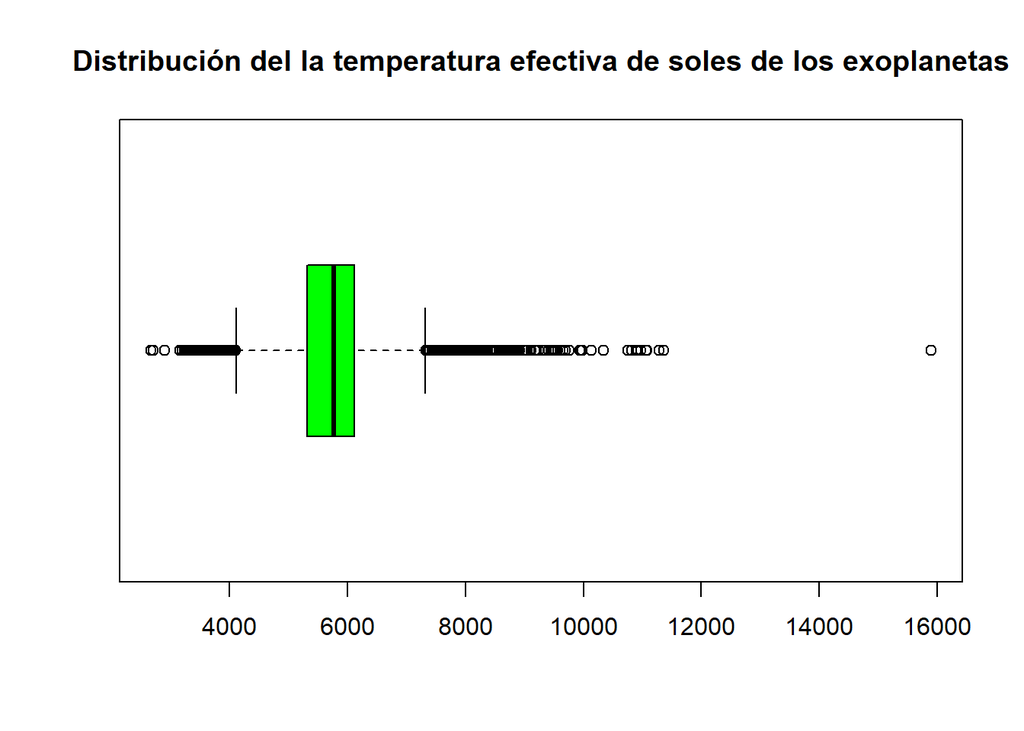

```r
caja_steff <- boxplot(exo_planetas_p3$koi_steff,horizontal=T,col="green", main="Distribución del la temperatura efectiva de soles de los exoplanetas")
```

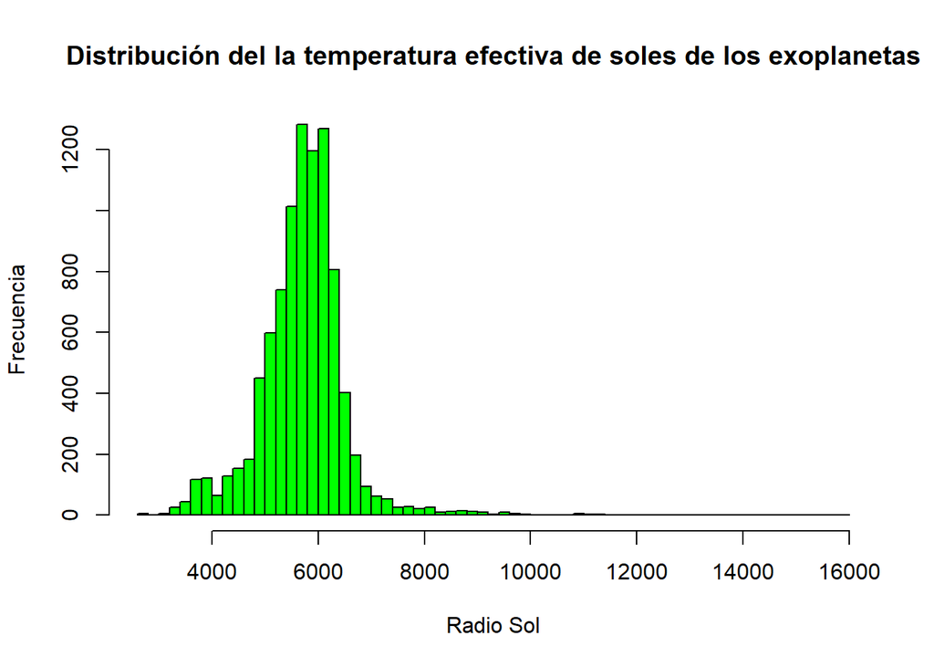

```r
hist_steff <- hist(exo_planetas_p3$koi_steff, main = "Distribución del la temperatura efectiva de soles de los exoplanetas", xlab = "Radio Sol", ylab = "Frecuencia", col = "green", breaks = 70)
```

```r
n <- length(hist_steff$breaks)
Tab_pl_steff <- cbind(hist_steff$breaks[-n],hist_steff$breaks[-1],
                hist_steff$counts,
                hist_steff$counts/sum(hist_steff$counts),
                cumsum(hist_steff$counts),
                cumsum(hist_steff$counts/sum(hist_steff$counts)))
dimnames(Tab_pl_steff)[[2]]<-c("Linf","Lsup","f","fr","F","Fr")

print(Tab_pl_steff)
```

```
##        Linf  Lsup    f           fr    F           Fr
##  [1,]  2600  2800    6 0.0006521030    6 0.0006521030
##  [2,]  2800  3000    1 0.0001086838    7 0.0007607869
##  [3,]  3000  3200    4 0.0004347354   11 0.0011955222
##  [4,]  3200  3400   25 0.0027170960   36 0.0039126182
##  [5,]  3400  3600   44 0.0047820889   80 0.0086947071
##  [6,]  3600  3800  116 0.0126073253  196 0.0213020324
##  [7,]  3800  4000  121 0.0131507445  317 0.0344527769
##  [8,]  4000  4200   65 0.0070644495  382 0.0415172264
##  [9,]  4200  4400  129 0.0140202152  511 0.0555374416
## [10,]  4400  4600  154 0.0167373112  665 0.0722747527
## [11,]  4600  4800  184 0.0199978263  849 0.0922725791
## [12,]  4800  5000  450 0.0489077274 1299 0.1411803065
## [13,]  5000  5200  599 0.0651016194 1898 0.2062819259
## [14,]  5200  5400  740 0.0804260406 2638 0.2867079665
```

[output cut: 53 more lines]

```r
library(fdth)
mean(exo_planetas_p4$koi_steff)
```

```
## [1] 5706.823
```

```r
median(exo_planetas_p4$koi_steff)
```

```
## [1] 5767
```

```r
mfv(exo_planetas_p4$koi_steff)
```

```
## [1] 5780
```

```r
max(exo_planetas_p4$koi_steff, na.rm = FALSE)
```

```
## [1] 15896
```

```r
min(exo_planetas_p4$koi_steff)
```

```
## [1] 2661
```

```r
range(exo_planetas_p4$koi_steff)
```

```
## [1]  2661 15896
```

```r
var(exo_planetas_p4$koi_steff)
```

```
## [1] 634982.6
```

```r
sd(exo_planetas_p4$koi_steff)
```

```
## [1] 796.8579
```

```r
mad(exo_planetas_p4$koi_steff)
```

```
## [1] 579.6966
```

```r
quantile(exo_planetas_p4$koi_steff, probs = c(0.25,0.50,0.75))
```

```
##  25%  50%  75%
## 5310 5767 6112
```

Esta es la variable que destaca por encima de todas por tener, en primer lugar una distribución más adecuada para el análisis exploratorio de datos, ya que, aunque hay todavía un sesgo de los datos hacia la izquierda, no es el caso extremo como lo es en las demás variables, en las que podemos ver solamente una barra pegada al eje de las frecuencias. Esto indica que los datos asociados a esta variable parecen ser más confiables, aunque no del todo. En la gráfica de caja se ve claramente que hay muchos datos fuera de los bigotes, y un dato que se encuentra claramente fuera, lo que nos indica que debió ser un error de medición, aunque nuevamente no hay suficiente información para poder llegar a conclusiones.

En este caso la varianza es muy alta nuevamente, por lo que el cálculo del promedio no es confiable.

Para hacer el análisis incluyendo la variable cualitativa formamos dos bases de datos nuevas en las que se tienen los exoplanetas confirmados y los exoplanetas que dieron falso positivo.

```r
exo_planetas_p5 <- dplyr::select(exo_planetas_p4, koi_disposition , koi_teq)
```

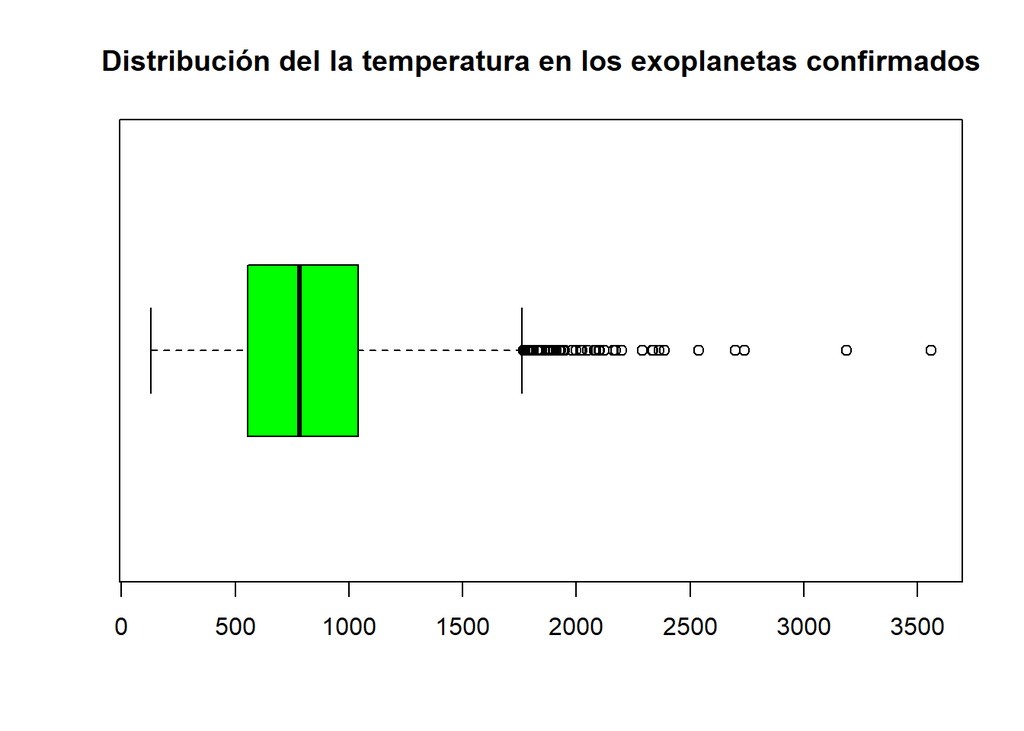

```r
exo_planetas_confirmados <- exo_planetas_p5 %>% dplyr::filter(koi_disposition == 'CONFIRMED') %>% group_by (koi_disposition)

caja_conft <- boxplot(exo_planetas_confirmados$koi_teq,horizontal=T,col="green", main="Distribución del la temperatura en los exoplanetas confirmados")
```

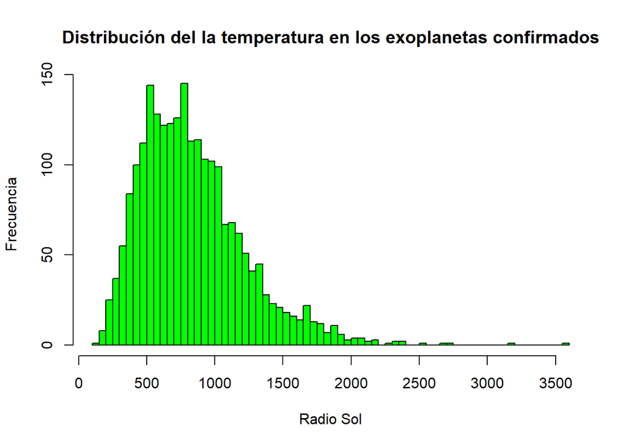

```r
hist_conft <- hist(exo_planetas_confirmados$koi_teq, main = "Distribución del la temperatura en los exoplanetas confirmados", xlab = "Radio Sol", ylab = "Frecuencia", col = "green", breaks = 70)
```

```r
n <- length(hist_conft$breaks)
Tab_pl_conft <- cbind(hist_conft$breaks[-n],hist_conft$breaks[-1],
                hist_conft$counts,
                hist_conft$counts/sum(hist_conft$counts),
                cumsum(hist_conft$counts),
                cumsum(hist_conft$counts/sum(hist_conft$counts)))
dimnames(Tab_pl_conft)[[2]]<-c("Linf","Lsup","f","fr","F","Fr")

print(Tab_pl_conft)
```

```
##       Linf Lsup   f           fr    F           Fr
##  [1,]  100  150   1 0.0004363002    1 0.0004363002
##  [2,]  150  200   8 0.0034904014    9 0.0039267016
##  [3,]  200  250  25 0.0109075044   34 0.0148342059
##  [4,]  250  300  37 0.0161431065   71 0.0309773124
##  [5,]  300  350  55 0.0239965096  126 0.0549738220
##  [6,]  350  400  84 0.0366492147  210 0.0916230366
##  [7,]  400  450 100 0.0436300175  310 0.1352530541
##  [8,]  450  500 112 0.0488656195  422 0.1841186736
##  [9,]  500  550 144 0.0628272251  566 0.2469458988
## [10,]  550  600 128 0.0558464223  694 0.3027923211
## [11,]  600  650 122 0.0532286213  816 0.3560209424
## [12,]  650  700 123 0.0536649215  939 0.4096858639
## [13,]  700  750 126 0.0549738220 1065 0.4646596859
## [14,]  750  800 145 0.0632635253 1210 0.5279232112
```

[output cut: 56 more lines]

```r
library(fdth)
mean(exo_planetas_confirmados$koi_teq)
```

```
## [1] 839.1257
```

```r
median(exo_planetas_confirmados$koi_teq)
```

```
## [1] 781
```

```r
mfv(exo_planetas_confirmados$koi_teq)
```

```
## [1] 678
```

```r
max(exo_planetas_confirmados$koi_teq, na.rm = FALSE)
```

```
## [1] 3559
```

```r
min(exo_planetas_confirmados$koi_teq)
```

```
## [1] 129
```

```r
range(exo_planetas_confirmados$koi_teq)
```

```
## [1]  129 3559
```

```r
var(exo_planetas_confirmados$koi_teq)
```

```
## [1] 149568.3
```

```r
sd(exo_planetas_confirmados$koi_teq)
```

```
## [1] 386.7406
```

```r
mad(exo_planetas_confirmados$koi_teq)
```

```
## [1] 354.3414
```

```r
quantile(exo_planetas_confirmados$koi_teq, probs = c(0.25,0.50,0.75))
```

```
##  25%  50%  75%
##  554  781 1039
```

Como podemos apreciar, los datos filtrados por variable cualitativa presentan sesgos muy parecidos a los de los datos previamente analizados, esto es extraño ya que esperábamos ver que los datos de los exoplanetas tuvieran consistencia entre sí, sin embargo por la falta de información no podemos decir que los datos que parecen no pertenecer a esta base de datos deban dejar de ser exoplanetas.

[figure not shown]

```r
exo_planetas_falsospositivos <- exo_planetas_p5 %>% dplyr::filter(koi_disposition == 'FALSE POSITIVE') %>% group_by (koi_disposition)

caja_falp <- boxplot(exo_planetas_falsospositivos$koi_teq,horizontal=T,col="green", main="Distribución del la temperatura en los exoplanetas confirmados")
```

[figure not shown]

```r
hist_falp <- hist(exo_planetas_falsospositivos$koi_teq, main = "Distribución del la temperatura en los exoplanetas confirmados", xlab = "Radio Sol", ylab = "Frecuencia", col = "green", breaks = 70)
```

```r
n <- length(hist_conft$breaks)
Tab_pl_falp <- cbind(hist_falp$breaks[-n],hist_falp$breaks[-1],
                hist_falp$counts,
                hist_falp$counts/sum(hist_falp$counts),
                cumsum(hist_falp$counts),
                cumsum(hist_falp$counts/sum(hist_falp$counts)))
dimnames(Tab_pl_falp)[[2]]<-c("Linf","Lsup","f","fr","F","Fr")

print(Tab_pl_falp)
```

```
##        Linf  Lsup   f          fr    F         Fr
##  [1,]     0   200  75 0.015876376   75 0.01587638
##  [2,]   200   400 715 0.151354784  790 0.16723116
##  [3,]   400   600 492 0.104149026 1282 0.27138019
##  [4,]   600   800 480 0.101608806 1762 0.37298899
##  [5,]   800  1000 403 0.085309060 2165 0.45829805
##  [6,]  1000  1200 409 0.086579170 2574 0.54487722
##  [7,]  1200  1400 363 0.076841660 2937 0.62171888
##  [8,]  1400  1600 338 0.071549534 3275 0.69326842
##  [9,]  1600  1800 320 0.067739204 3595 0.76100762
## [10,]  1800  2000 271 0.057366638 3866 0.81837426
## [11,]  2000  2200 208 0.044030483 4074 0.86240474
## [12,]  2200  2400 150 0.031752752 4224 0.89415749
## [13,]  2400  2600 111 0.023497036 4335 0.91765453
## [14,]  2600  2800  90 0.019051651 4425 0.93670618
```

[output cut: 60 more lines]

```r
library(fdth)
mean(exo_planetas_falsospositivos$koi_teq)
```

```
## [1] 1298.745
```

```r
median(exo_planetas_falsospositivos$koi_teq)
```

```
## [1] 1095
```

```r
mfv(exo_planetas_falsospositivos$koi_teq)
```

```
## [1] 706
```

```r
max(exo_planetas_falsospositivos$koi_teq, na.rm = FALSE)
```

```
## [1] 14667
```

```r
min(exo_planetas_falsospositivos$koi_teq)
```

```
## [1] 92
```

```r
range(exo_planetas_falsospositivos$koi_teq)
```

```
## [1]    92 14667
```

```r
var(exo_planetas_falsospositivos$koi_teq)
```

```
## [1] 1057033
```

```r
sd(exo_planetas_falsospositivos$koi_teq)
```

```
## [1] 1028.121
```

```r
mad(exo_planetas_falsospositivos$koi_teq)
```

```
## [1] 856.9428
```

```r
quantile(exo_planetas_falsospositivos$koi_teq, probs = c(0.25,0.50,0.75))
```

```
##     25%     50%     75%
##  566.00 1095.00 1764.25
```

Para esta base de datos filtrados podemos observar que los sesgos y patrones de los datos previamente analizados se conservan, lo cuál era de esperarse ya que para que los planetas no sean considerados exoplanetas consideramos que no deberían necesariamente tener una temperatura similar entre sí. Nuevamente nos encontramos en una situación en la que no hay posibilidades de concluir ya que nos hace falta mucha información.

Finalmente haremos un análisis cualitativo de la variable del radio planetario, como ya conocemos el máximo vamos a subdividir a los planetas en tamaños, Súper, Grande, Mediano, Chico y Diminuto.

Planeta diminuto: 0 a 40069 Planeta chico: 40069 a 80138 Planeta mediano: 80138 a 120207 Planeta grande: 120207 a 160276 Planeta súper: 160276 a 200346

```r
exo_vector<- as.vector(exo_planetas_p4['koi_prad'])
max(exo_planetas_p4$koi_prad)
```

```
## [1] 200346
```

```r
exo_pl7 <- NA
exo_pl7[exo_planetas_p4$koi_prad >= 0 & exo_planetas_p4$koi_prad <= 40080] <- 'Diminuto'
exo_pl7[exo_planetas_p4$koi_prad > 40080 & exo_planetas_p4$koi_prad <= 80200] <- 'Chico'
exo_pl7[exo_planetas_p4$koi_prad > 80200 & exo_planetas_p4$koi_prad <= 120300] <- 'Mediano'
exo_pl7[exo_planetas_p4$koi_prad > 120300 & exo_planetas_p4$koi_prad <= 160300] <- 'Grande'
exo_pl7[exo_planetas_p4$koi_prad > 160300 & exo_planetas_p4$koi_prad <= 200500] <- 'Súper'

(tabla4 = table(exo_pl7))
```

```
## exo_pl7
##    Chico Diminuto  Mediano    Súper
##        2     9196        1        2
```

De esta tabla podemos ver que ni si quiera hay datos grandes, por lo que ya hay indicios de que esta forma de analizar no es adecuada para esta variable.

[figure not shown]

```r
barplot(tabla4,names.arg=c("Diminuto","Chico","Mediano",'Súper'), col=3, ylim=c(0,750), main = "Gráfica de barras de exoplanetas por radio")
```

[figure not shown]

```r
pie(tabla4,labels=paste(c("Súper","Mediano","Pequeño","Diminuto"),tabla4,sep=":"), col=5:7, radius=1,main = "Grafica de pie de exoplanetas por radio")
```

Es notable que ninguno de los recursos gráficos es adecuado para estudiar esta variable.

Aunque no sea adecuado analizar, la única información que podemos recuperar es la del cesgo hacia la izquierda, por lo tanto, del análisis exploratorio podemos ver que el sesgo que vimos en el análisis de las variables cuantitativas también aparece en el análisis cualitativo.

```r
#Primero "depuraremos" la información eliminando los NA's y repetidos

setwd("C:/Users/114738/OneDrive/Escritorio/Proyectos")
kepler = read.csv('/Users/114738/OneDrive/Escritorio/Proyectos/cumulative.csv')

library(dplyr)
kepler1 = dplyr::select(kepler, kepoi_name, koi_prad, koi_teq, koi_period, koi_srad, koi_steff)
kepler2 = kepler1 %>% group_by(kepoi_name) %>%
dplyr::filter (! duplicated(kepoi_name))
library(tidyr)
kepler3 = drop_na(kepler2)
attach(kepler3)
```

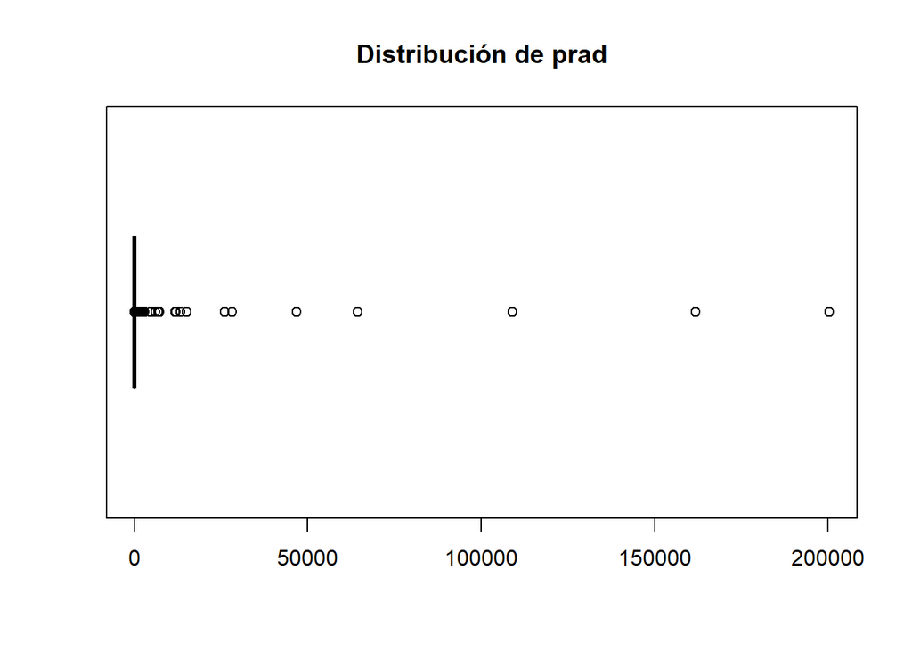

```r
#Procedemos a ver la distribución de datos en cada variable
boxplot(koi_prad,horizontal=T,col="yellow",main="Distribución de prad")
```

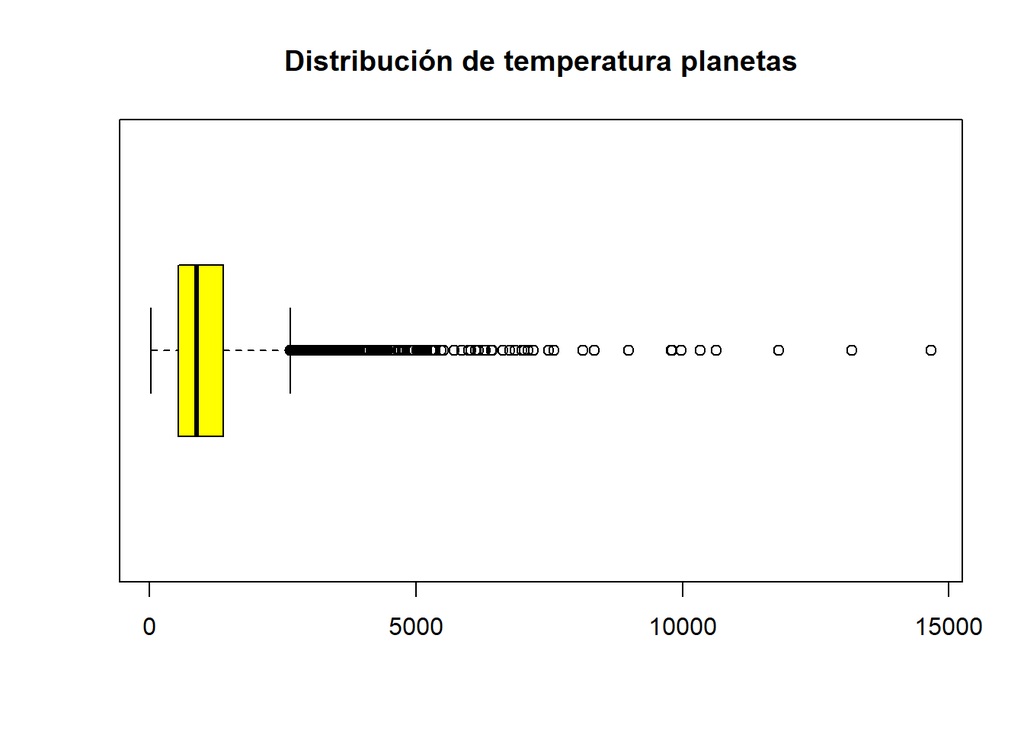

```r
boxplot(koi_teq,horizontal=T,col="yellow",main="Distribución de temperatura planetas")
```

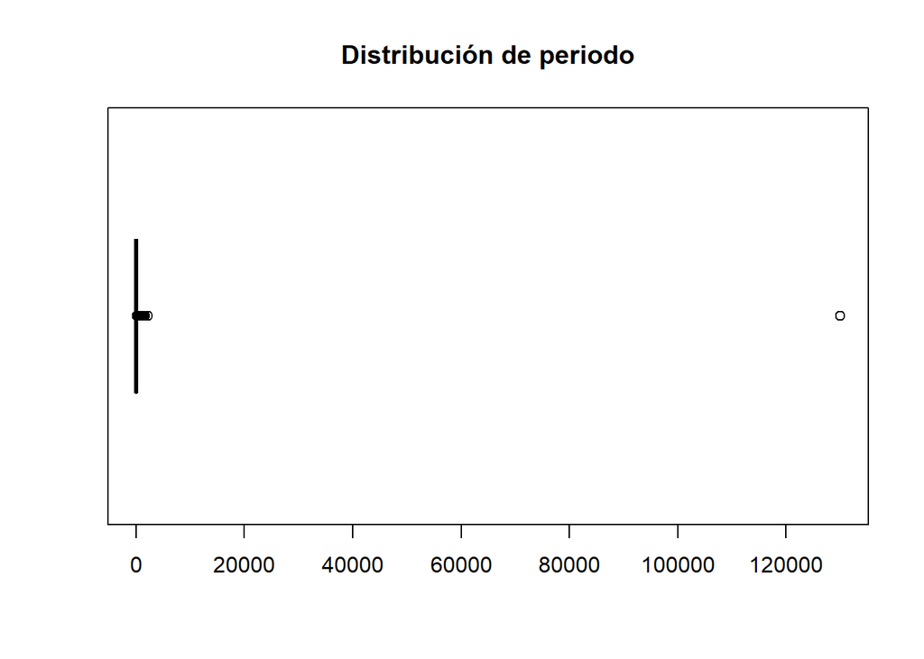

```r
boxplot(koi_period,horizontal=T,col="yellow",main="Distribución de periodo")
```

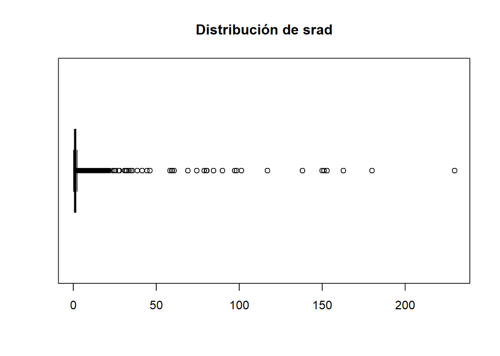

```r
boxplot(koi_srad,horizontal=T,col="yellow",main="Distribución de srad")
```

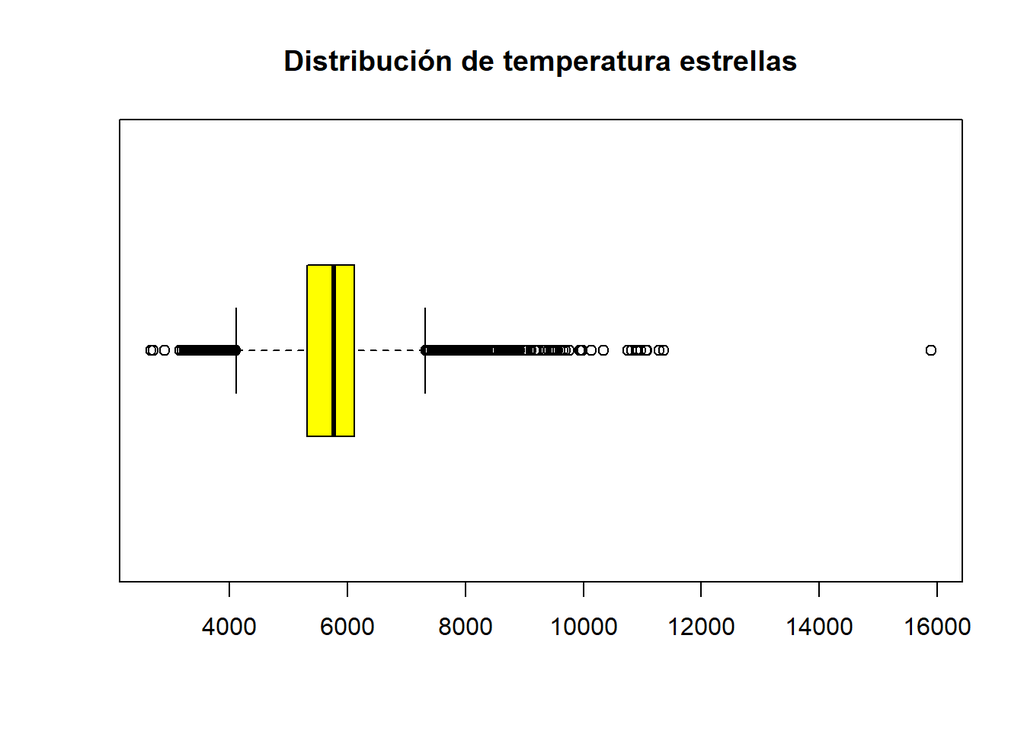

```r
boxplot(koi_steff,horizontal=T,col="yellow",main="Distribución de temperatura estrellas")
```

```r
#Tomaremos la variable cuantitativa koi_steff
mean(koi_steff)
```

```
## [1] 5706.823
```

```r
var(koi_steff)
```

```
## [1] 634982.6
```

```r
sd(koi_steff)
```

```
## [1] 796.8579
```

```r
max(koi_steff)
```

```
## [1] 15896
```

```r
min(koi_steff)
```

```
## [1] 2661
```

[figure not shown]

```r
hist(koi_steff, main = "Distribución de masa en exoplanetas", xlab = "Masas Terrestres", ylab = "Frecuencia", col = "blue")
```

```r
#Propondremos el modelo probabilístico de la distribución Gamma
#Para determinar alfa y beta procederemos a resolver el sistema de ecuaciones de #2 incógnitas usando las relaciones entre alfa, beta con el promedio y la #varianza, donde miu = promedio, v = varianza, b = beta y a = alfa, tendremos:
#miu = a*b y v = a*b^2 con cuentitas queda a = miu^2/v y b = v/miu

alfa = mean(koi_steff)^2/var(koi_steff)
beta = var(koi_steff)/mean(koi_steff)
"Valor de alfa"
```

```
## [1] "Valor de alfa"
```

```r
alfa
```

```
## [1] 51.28933
```

```r
"Valor de Beta"
```

```
## [1] "Valor de Beta"
```

```r
beta
```

```
## [1] 111.2673
```

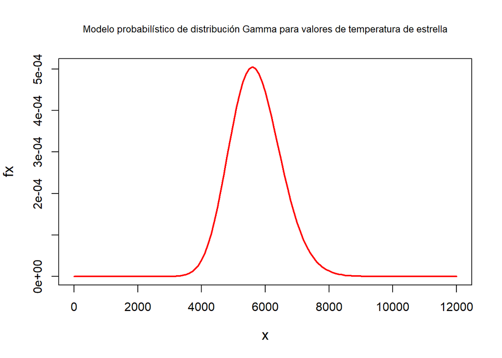

```r
plot(x=seq(0,12000,100),dgamma(x=seq(0,12000,100),shape = 51.28933,scale=111.2673),type = "l",col="red",lwd=2,xlab="x",ylab="fx", cex.lab=1.2,main=expression(paste("Modelo probabilístico de distribución Gamma para valores de temperatura de estrella")),cex.main=0.8)
```

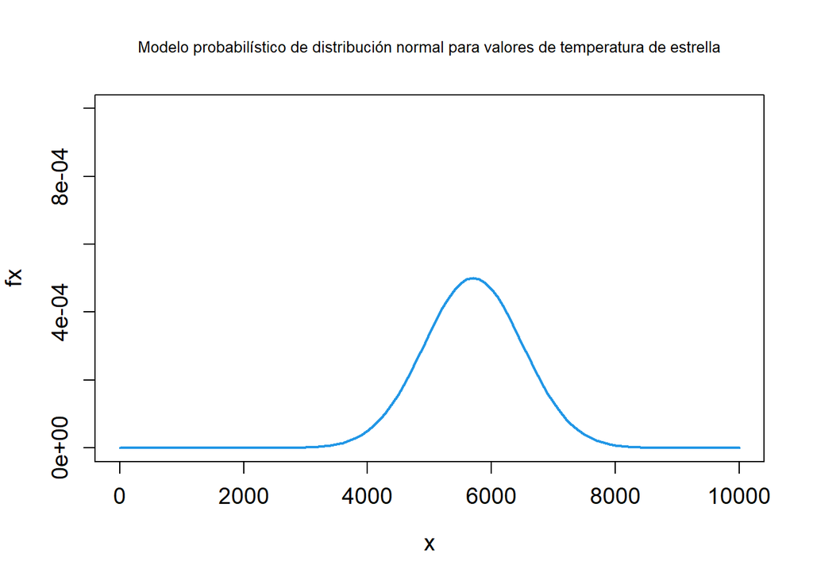

```r
#Al no contar con un modelo teórico procedemos con el 2° modelo probabilístico

plot(x=seq(0,10000,100), dnorm(x=seq(0,10000,100), mean=5706.823, sd=796.8579),type ="l",col=4,lwd=2,xlab="x",ylab="fx",ylim=c(0,0.001),cex.axis=1.2, cex.lab=1.2,main=expression(paste("Modelo probabilístico de distribución normal para valores de temperatura de estrella")),cex.main=0.8)
```

**Los modelos probabilísticos anteriores fueron seleccionados debido a que los valores que se pueden tomar son positivos, por lo cual la distribución gamma fue un excelente candidato, además que podía ser capaz de modelar una subida y bajada en los datos relativamente suave. Por otra parte, la distribución normal fue elegida ya que se observa una clara acumulación de datos entorno a un valor medio, si dejamos de tener en cuenta un par de datos atípicos y es bastante común usarla para este tipo de casos.**

```r
#Usaremos el método más sencillo que es usar la librería MASS, la cual estima puntualmente los parámetros deseados de nuestros modelos mediante el método de máxima verosimilitud.

library(MASS)
kepler_mle1 = fitdistr(koi_steff, densfun="gamma")

library(MASS)
kepler_mle2 = fitdistr(koi_steff, densfun="normal")

#Recordemos que en "kepler_mle1" la estimación puntual de Beta, se reporta su inverso.
kepler_mle1
```

```
##       shape           rate
##   5.128933e+01   8.987388e-03
##  (5.552211e-01) (9.715997e-05)
```

```r
kepler_mle2
```

```
##       mean           sd
##   5706.823280    796.814643
##  (   8.306915) (   5.873876)
```

```r
#Notemos que nos resulta, lo mismo que anteriormente habíamos calculado
```

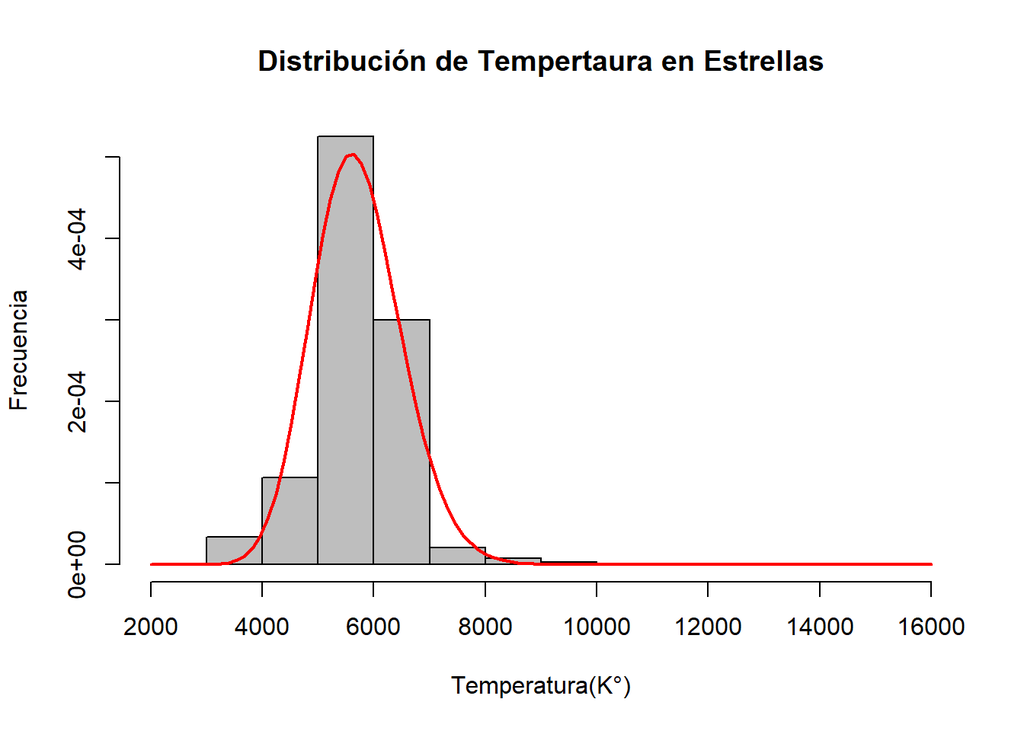

```r
hist(koi_steff, prob=TRUE,main = "Distribución de Tempertaura en Estrellas", ylab = "Frecuencia", col = "grey", xlab="Temperatura(K°)")
curve(dgamma(x, kepler_mle1$estimate[1], kepler_mle1$estimate[2]),col="red",lwd=2,add=T)
```

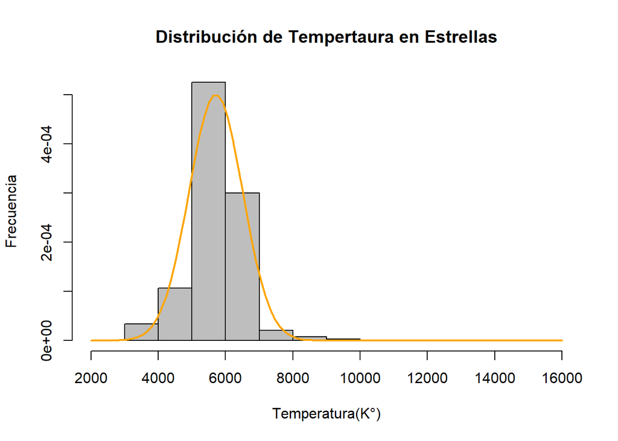

```r
hist(koi_steff, prob=TRUE,main = "Distribución de Tempertaura en Estrellas", ylab = "Frecuencia", col = "grey", xlab="Temperatura(K°)")
curve(dnorm(x, kepler_mle2$estimate[1], kepler_mle2$estimate[2]),col="orange",lwd=2,add=T)
```

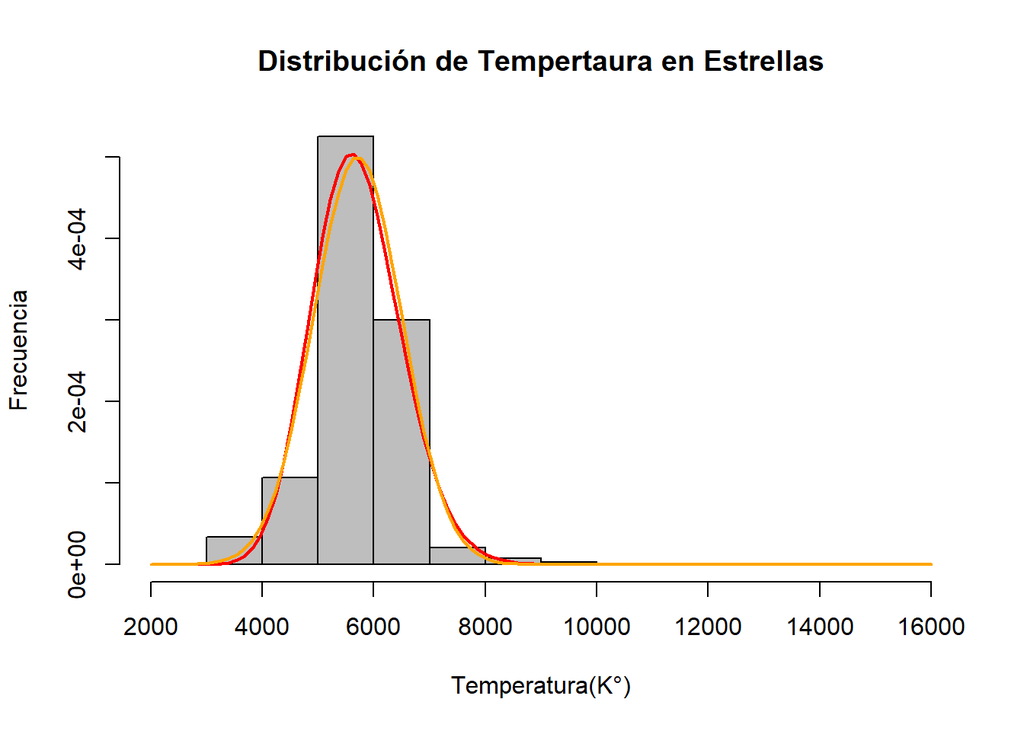

```r
hist(koi_steff, prob=TRUE,main = "Distribución de Tempertaura en Estrellas", ylab = "Frecuencia", col = "grey", xlab="Temperatura(K°)")
curve(dgamma(x, kepler_mle1$estimate[1], kepler_mle1$estimate[2]),col="red",lwd=2,add=T)
curve(dnorm(x, kepler_mle2$estimate[1], kepler_mle2$estimate[2]),col="orange",lwd=2,add=T)
```

```r
#Ambos modelos se ven similares por lo que para decidir el mejor modelo usaremos:
library(univariateML)
library(dplyr)
library(tibble)
comparacion_aic <- AIC(mlgamma(koi_steff),mlnorm(koi_steff))
comparacion_aic
```

```
##                    df      AIC
## mlgamma(koi_steff)  2 148970.5
## mlnorm(koi_steff)   2 149052.1
```

**Notamos que el valor de AIC en el modelo probabilístico de Gamma es menor, por lo que es el mejor entre ambos. Cabe destacar que la diferencia entre los modelos es pequeña, justo como lo esperabamos, ya que a pura vista se veían igual de apropiados**

```r
#La variable cualitativa en nuestro proyecto corresponde a koi_disposition, que básicamente es una variable la cual clasifica como confirmados, candidatos o falsos positivos a algunas observaciones. La relación con la variable cuantitativa de koi_steff (es temperatura de estrellas) es nula, por lo tanto convertiremos la variable koi_srad (radio de estrellas) a variable cualitativa

max(koi_srad)
```

```
## [1] 229.908
```

```r
min(koi_srad)
```

```
## [1] 0.109
```

```r
mean(koi_srad)
```

```
## [1] 1.728712
```

```r
sd(koi_srad)
```

```
## [1] 6.127185
```

```r
#Si la cualitativa la dividiamos en intervalos iguales, nos resulta que al rededor del 99.7% de los datos caían en la misma categoría, para hacer más interesante el análisis los dividiremos arbitrariamente (a conveniencia) de 0 a 1 serán aquellas estrellas de menor tamaño que el Sol y consideramos que de 1 a 3 la estrella es de tamaño parecido a la nuestra y así sucesivamente hasta llegar a los grandes, enormes y super.

kepler4 <- NA
kepler4[kepler3$koi_srad >= 0 & kepler3$koi_srad <= 1] <- 'Pequeño'
kepler4[kepler3$koi_srad > 1 & kepler3$koi_srad <= 3] <- 'Normal'
kepler4[kepler3$koi_srad > 3 & kepler3$koi_srad <= 25] <- 'Grande'
kepler4[kepler3$koi_srad > 25 & kepler3$koi_srad <= 45] <- 'Enorme'
kepler4[kepler3$koi_srad > 45 & kepler3$koi_srad <= 230] <- 'Super'

(tabla_radios = table(kepler4))
```

```
## kepler4
##  Enorme  Grande  Normal Pequeño   Super
##      14     514    3944    4705      24
```

```r
library(dplyr)
kepler5 = dplyr::select(kepler3,kepoi_name,koi_srad, koi_steff)
kepler5 <- cbind(kepler5,kepler4)
#Agrupamos los datos de temperatura con base a la clasificación de tamaño
temp_peque = kepler5[kepler5$...4 == "Pequeño", 3]
temp_norm = kepler5[kepler5$...4 == "Normal", 3]
temp_gran = kepler5[kepler5$...4 == "Grande", 3]
temp_enor = kepler5[kepler5$...4 == "Enorme", 3]
temp_sup = kepler5[kepler5$...4 == "Super", 3]
```

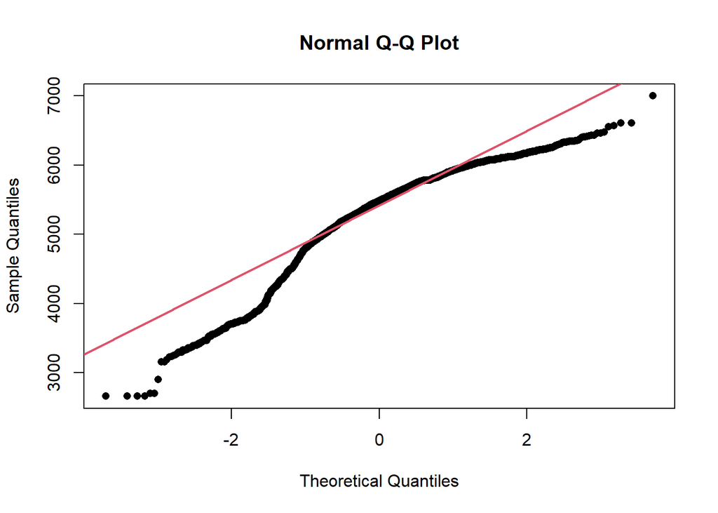

```r
qqnorm(temp_peque$koi_steff,pch=16)
qqline(temp_peque$koi_steff,lwd=2,col=2)
```

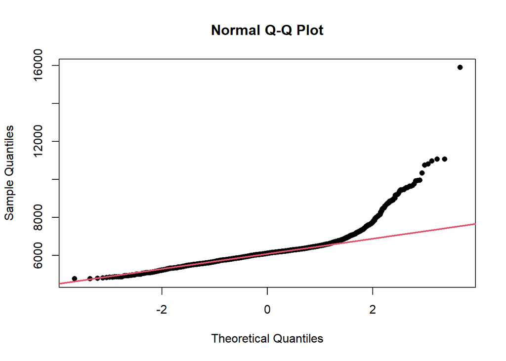

```r
qqnorm(temp_norm$koi_steff,pch=16)
qqline(temp_norm$koi_steff,lwd=2,col=2)
```